# Introduction to Stan

Last updated: 2019-10-23

## Overview

- Anatomy of a Stan model
- Stan analysis of the `sleepstudy` dataset (stan-example1.R)
- The `rstan` package
- A more complex example that (I think) cannot be estimated with `brms` (stan-example2.R)

## Anatomy of a Stan model

## Anatomy of a Stan model

Necessary blocks (more info [here](https://mc-stan.org/docs/2_18/reference-manual/blocks-chapter.html))

```r
data {
  \\ what we are modeling
}
parameters {
  \\ the variables being sampled by Stan
}
model {
  \\ priors and likelihood function
}
```

## Anatomy of a Stan model

Optional blocks (more info [here](https://mc-stan.org/docs/2_18/reference-manual/blocks-chapter.html))

```r
functions {
  \\ user defined functions
}
transformed data {
  \\ as the name suggests
}
transformed parameters {
  \\ sometimes useful to speed up program
}
generated quantities {
  \\ does things with the samples
  \\ e.g., calculate log likelihood, posterior predictions
}
```

## `brms::stancode`

- You can see the code that `brms` produces
- Probably of limited use until familiar with the intricacies of `Stan`…

```r
stancode(m1)
```

```
## // generated with brms 2.9.0
## functions {
## }
## data {
##   int<lower=1> N;  // number of observations
##   vector[N] Y;  // response variable
##   int<lower=1> K;  // number of population-level effects
##   matrix[N, K] X;  // population-level design matrix
##   int prior_only;  // should the likelihood be ignored?
## }
## transformed data {
##   int Kc = K - 1;
##   matrix[N, Kc] Xc;  // centered version of X
##   vector[Kc] means_X;  // column means of X before centering
##   for (i in 2:K) {
##     means_X[i - 1] = mean(X[, i]);
##     Xc[, i - 1] = X[, i] - means_X[i - 1];
##   }
## }
## parameters {
##   vector[Kc] b;  // population-level effects
##   real temp_Intercept;  // temporary intercept
##   real<lower=0> sigma;  // residual SD
## }
## transformed parameters {
## }
## model {
##   vector[N] mu = temp_Intercept + Xc * b;
##   // priors including all constants
##   target += normal_lpdf(b | 0, 50);
##   target += normal_lpdf(temp_Intercept | 500, 100);
##   target += cauchy_lpdf(sigma | 0, 50)
##     - 1 * cauchy_lccdf(0 | 0, 50);
##   // likelihood including all constants
##   if (!prior_only) {
##     target += normal_lpdf(Y | mu, sigma);
##   }
## }
## generated quantities {
##   // actual population-level intercept
##   real b_Intercept = temp_Intercept - dot_product(means_X, b);
## }
```

## stan-example1.R

## `sleepstudy` Example

```r
sleepstudy <- read.csv("../examples/sleepstudy.csv")
head(sleepstudy)
```

```
##   Reaction Days Subject
## 1 249.5600    0     308
## 2 258.7047    1     308
## 3 250.8006    2     308
## 4 321.4398    3     308
## 5 356.8519    4     308
## 6 414.6901    5     308
```

## `data`

```r
data {
  int<lower=0> N;             // n observations
  vector[N] y;                // reaction times
  matrix[N,2] x;              // design matrix (intercept, days)
  int<lower=0> S;             // n subjects
  int<lower=1,upper=S> id[N]; // subject ids
}
```

More on [data types](https://mc-stan.org/docs/2_18/reference-manual/data-types-chapter.html)

## `parameters`

Below are the parameters for the simple (non-hierarchical) regression model (model 1)

```r
parameters {
  vector[2] beta;             // fixed effects
  real<lower=0> sigma;        // residual SD
}
```

## `model`

```r
model {
  // priors
  sigma ~ cauchy(0,50);
  beta[1] ~ normal(300,100);
  beta[2] ~ normal(0,50);
  // likelihood
  y ~ normal(x * beta, sigma);
}
```

- `~` sampling statement (is distributed as)
- `=` assignment

## `generated quantities`

```r
generated quantities {
  vector[N] log_lik;      // log likelihood matrix
  vector[N] y_rep;        // posterior predictions
  for (i in 1:N){
    log_lik[i] = normal_lpdf(y[i] | x[i] * beta, sigma);
    y_rep[i] = normal_rng(x[i] * beta, sigma);
  }
}
```

- `log_lik`: log likelihood matrix. Used for calculating loo, waic
- `y_rep`: samples from the posterior predictive distribution

## `.stan`

- These blocks are all bundled into a `.stan` file
- See "examples/stan-models/example1-m1.stan" for this example program
- We can use the `rstan` package to get samples

## The `rstan` package

## `rstan`

Is the interface between `R` and `Stan`

Steps:

1. Put data into a list
2. Call the `stan()` function
3. Do stuff with the samples

## Data list with `sleepstudy`

Everything in the `data` block should appear here

```r
data_list = list(
  N = nrow(sleepstudy),
  y = sleepstudy$Reaction,
  x = model.matrix(~ Days, data = sleepstudy),
  S = length(unique(sleepstudy$Subject)),
  id = as.numeric(sleepstudy$Subject) # ids should go from 1:S
)
```

```r
head(model.matrix(~ Days, data = sleepstudy))
```

```
##   (Intercept) Days
## 1           1    0
## 2           1    1
## 3           1    2
## 4           1    3
## 5           1    4
## 6           1    5
```

## Run samples with `stan()`

```r
m1_fit <- stan(
  file = "examples/stan-models/example1-m1.stan",
  data = data_list,
  chains = 4,
  warmup = 1000,
  iter = 2000,
  cores = 4
)
```

This runs 4 separate chains for 2000 samples (each) and discards the first 1000 (4000 post-warmup samples total)

## `stanfit` object

```r
summary(m1_fit, pars="beta")
```

```
## $summary
##              mean    se_mean       sd       2.5%        25%       50%
## beta[1] 251.76398 0.16539275 6.491386 239.453442 247.258025 251.70827
## beta[2]  10.41214 0.03121724 1.225763   7.982203   9.583671  10.42545
##               75%     97.5%    n_eff     Rhat
## beta[1] 256.11932 264.80592 1540.430 1.001449
## beta[2]  11.23338  12.78563 1541.786 1.001285
##
## $c_summary
## , , chains = chain:1
##
##          stats
## parameter      mean       sd       2.5%        25%       50%      75%
##   beta[1] 252.18485 6.199706 240.454114 247.815557 252.18810 256.4569
##   beta[2]  10.34775 1.197131   8.144191   9.519118  10.33167  11.2013
##          stats
## parameter     97.5%
##   beta[1] 264.32615
##   beta[2]  12.71495
##
## , , chains = chain:2
##
##          stats
## parameter      mean       sd       2.5%        25%       50%       75%
##   beta[1] 251.09433 6.561762 238.063821 246.900164 251.05603 255.36666
##   beta[2]  10.53161 1.229493   8.157186   9.770842  10.54947  11.26926
##          stats
## parameter    97.5%
##   beta[1] 263.8209
##   beta[2]  12.8721
##
## , , chains = chain:3
##
##          stats
## parameter     mean       sd       2.5%        25%       50%       75%
##   beta[1] 252.0068 6.810458 240.117147 246.866334 251.82382 257.11558
##   beta[2]  10.3642 1.289483   7.860059   9.493704  10.39578  11.23063
##          stats
## parameter    97.5%
##   beta[1] 266.2976
##   beta[2]  12.8516
##
## , , chains = chain:4
##
##          stats
## parameter      mean       sd       2.5%        25%       50%       75%
##   beta[1] 251.76997 6.333901 239.538124 247.519880 251.77943 255.68963
##   beta[2]  10.40501 1.177353   8.059835   9.637577  10.39035  11.23571
##          stats
## parameter     97.5%
##   beta[1] 264.38371
##   beta[2]  12.77676
```

## `stanfit` object

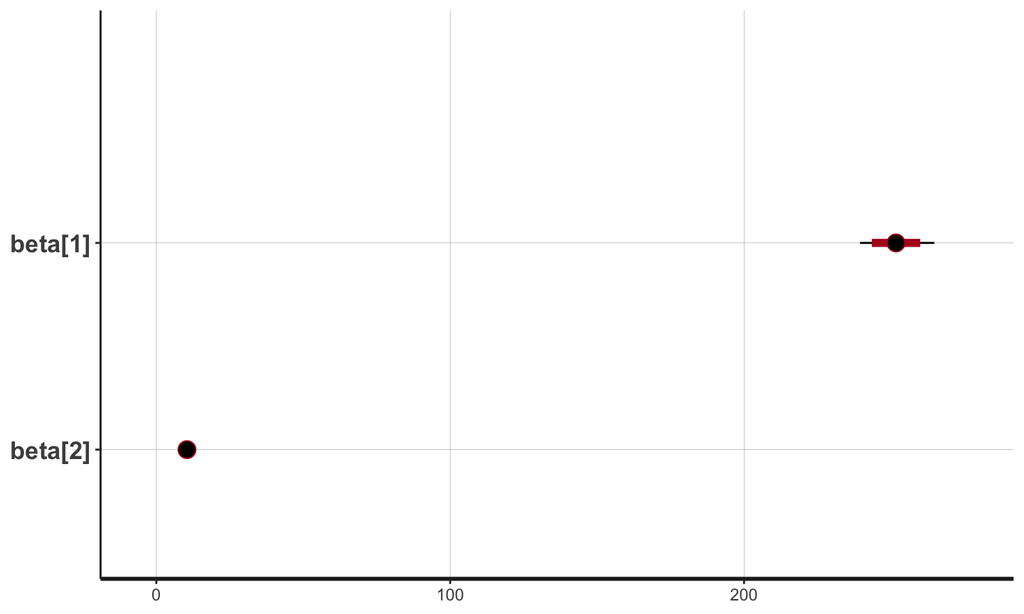

```r
plot(m1_fit, pars="beta")
```

## `stanfit` object

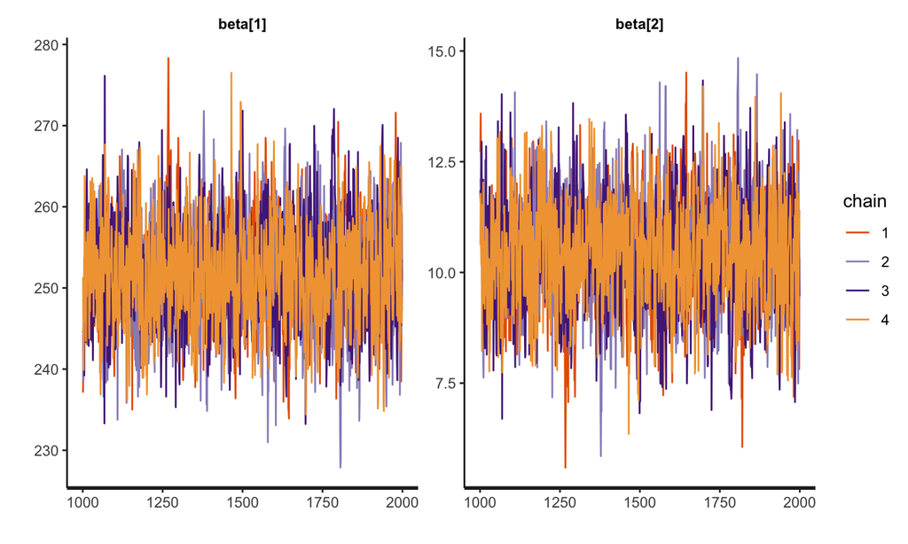

```r
traceplot(m1_fit, pars="beta")
```

## Posterior predictive check

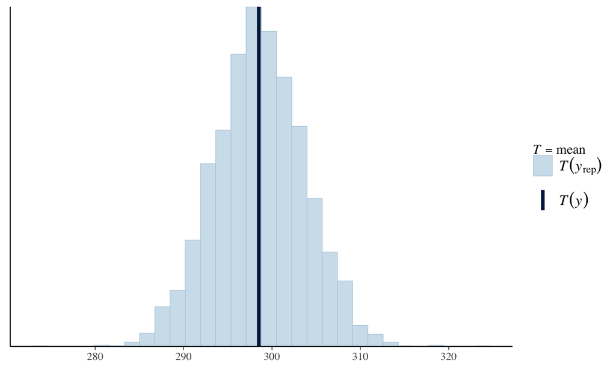

```r
yrep <- extract(m1_fit, pars = "y_rep")[[1]]
ppc_stat(sleepstudy$Reaction, yrep, stat = "mean")
```

## Posterior predictive check

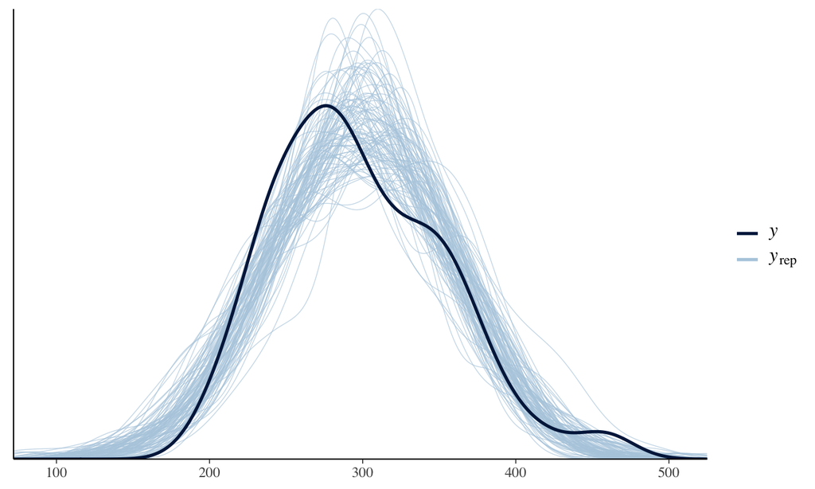

```r
# like pp_check()
ppc_dens_overlay(sleepstudy$Reaction, yrep[sample(nrow(yrep), size = 100),])
```

## `loo`

Using the [`loo` package](https://cran.r-project.org/web/packages/loo/index.html)

```r
log_lik_1 = extract_log_lik(m1_fit, merge_chains = F)
r_eff_1 = relative_eff(exp(log_lik_1))
loo_1 = loo(log_lik_1, r_eff = r_eff_1)
```

```r
loo_1
```

```
##
## Computed from 4000 by 180 log-likelihood matrix
##
##          Estimate   SE
## elpd_loo   -953.3 10.5
## p_loo         3.2  0.5
## looic      1906.5 21.0
## ------
## Monte Carlo SE of elpd_loo is 0.0.
##
## All Pareto k estimates are good (k < 0.5).
## See help('pareto-k-diagnostic') for details.
```

## Marginal likelihood (for Bayes factors)

Using the [`bridgesampling` package](https://cran.r-project.org/web/packages/bridgesampling/index.html)

```r
ml_1 = bridge_sampler(m1_fit)
```

```r
ml_1
```

```
## Bridge sampling estimate of the log marginal likelihood: -780.3699
## Estimate obtained in 5 iteration(s) via method "normal".
```

## stan-example2.R

### fairly complex model

## 2D recall data

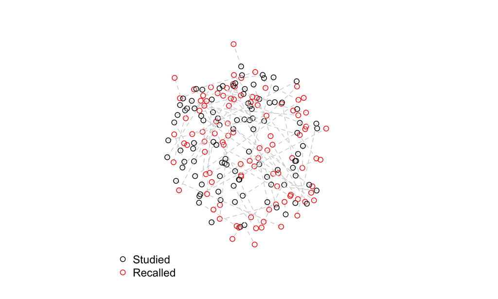

- Data from a hypothetical study where participants study the location of an item
- Then recall the location later on

## 2D recall data

`px` & `py` = presented x,y coordinates; `rx` & `ry` = recalled coordinates

```r
head(recall_2d)
```

```
##   trial id     px     py     rx     ry
## 1     1  1 -1.429  3.498 -1.868  2.025
## 2     2  1 -5.425  3.468 -5.292  0.948
## 3     3  1  6.418  0.423  6.349 -2.196
## 4     4  1  2.452  5.556  6.790  4.386
## 5     5  1  2.148 -3.260  0.637 -2.001
## 6     6  1  0.440  3.700 -1.794  5.962
```

## 2D recall data

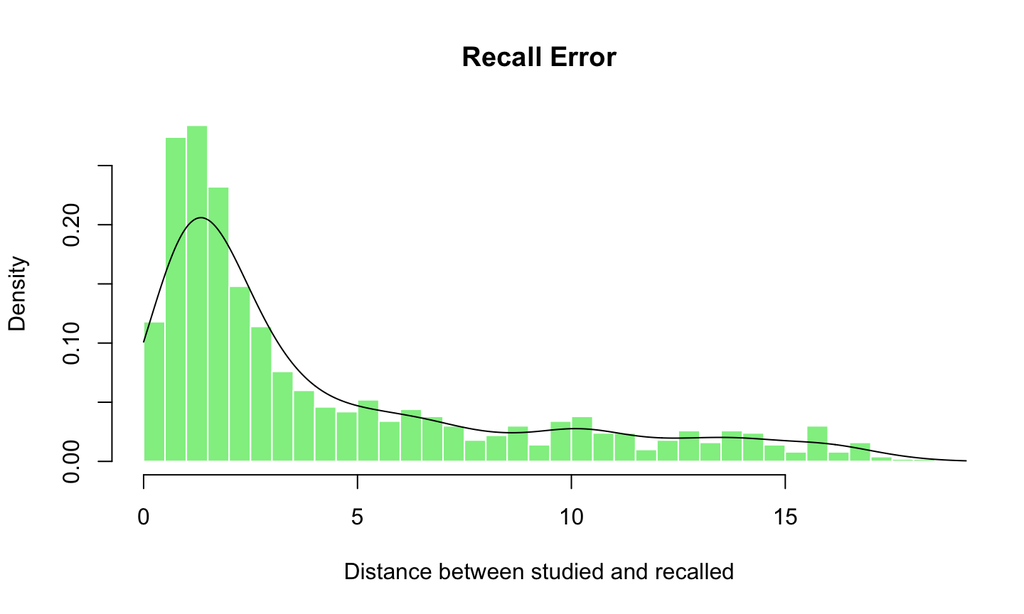

## Mixture model

```
Distribution of recalled locations = mixture of responses from memory and guesses
```

\[ \mathbf{r}_{ij} \sim m_i \times \phi(\mathbf{p}_j, s_i) + (1 - m_i) \times \frac{1}{A} \]

- \(i\) = Individuals; \(j\) = trials
- \(\mathbf{r}\) = recalled location, \(\mathbf{p}\) = presented (studied) location.
- \(m_i\) = probability of a response from memory for individual \(i\)
- \(s_i\) = imprecision of memory for individual \(i\)
- \(A\) = area where responses are allowed

## Mixture model

\[ \mathbf{r}_{ij} \sim m_i \times \phi(\mathbf{p}_j, s_i) + (1 - m_i) \times \frac{1}{A} \]

\[ \mbox{logit}(m_i) \sim \mbox{Normal}(\mu_m, \sigma_m) \\ \mbox{log}(s_i) \sim \mbox{Normal}(\mu_s, \sigma_s) \]

We need priors for the population level parameters, \(\mu_m\), \(\mu_s\), \(\sigma_m\), and \(\sigma_s\)

## example2.stan

```r
data {
  int<lower=0> N;             // N observations
  int<lower=0> S;             // number of participants
  int<lower=1,upper=S> id[N]; // participant id
  vector[N] p_x;              // presented x coordinate
  vector[N] p_y;              // presented y coordinate
  vector[N] r_x;              // recalled x coordinate
  vector[N] r_y;              // recalled y coordinate
  real<lower=0> A;            // for determining uniform (guess) density
}
```

## example2.stan

```r
parameters {
  real mu_m;                  // population mean for m (logit scale)
  real mu_s;                  // population mean for s (log scale)

  real<lower=0> sd_m;         // population sd for m (logit)
  real<lower=0> sd_s;         // population sd for s (log)

  vector[S] m;                // individual m parameters (logit)
  vector[S] s;                // individual s parameters (log)
}
```

\[ \mbox{logit}(m_i) \sim \mbox{Normal}(\mu_m, \sigma_m) \\ \mbox{log}(s_i) \sim \mbox{Normal}(\mu_s, \sigma_s) \]

## example2.stan

```r
model {
  // priors
  sd_m ~ cauchy(0,2.5);
  sd_s ~ cauchy(0,2.5);
  mu_m ~ normal(0,5);
  mu_s ~ normal(0,5);

  // sample individual parameters from population
  for (i in 1:S){
    m[i] ~ normal(mu_m, sd_m);
    s[i] ~ normal(mu_s, sd_s);
  }
... // continued on next slide
```

\[ \mbox{logit}(m_i) \sim \mbox{Normal}(\mu_m, \sigma_m) \\ \mbox{log}(s_i) \sim \mbox{Normal}(\mu_s, \sigma_s) \]

## example2.stan

```r
  // likelihood
  for (n in 1:N)
    target += log_mix(inv_logit(m[id[n]]),
                      normal_lpdf(r_x[n] | p_x[n], exp(s[id[n]])) +
                      normal_lpdf(r_y[n] | p_y[n], exp(s[id[n]])),
                      log(1/A));
}
```

Not quite the same, but equivalent to…

\[ \mathbf{r}_{ij} \sim m_i \times \phi(\mathbf{p}_j, s_i) + (1 - m_i) \times \frac{1}{A} \]

## stan-example2.R

Run through script…